# Final Project Pt 1 R Reference

Chloe Lang

12/16/2021

# R Reference Guide

## Loading Data & Packages

### The require () function

This can be used to load packages from the environment that have already been downloaded. This can be used to find the here() function.

```r
require(here)
```

### library () and here() functions

The library () function also can pull packages into our environment. This can be done with the “palmerpenguins” package.

```r
library(palmerpenguins)
```

### here() and read.csv()

The here() function can be used to look for data that is in a specific path or “directory” for each project environment. Read.csv() allows to read excel or data files into r-readable data frames.

```r
ginkgo = read.csv(here("ginkgo_data_2021.csv"))
```

## Data Structures

### c()

The function c() combines or concatenates its arguments into a vector (a 1-dimensional data structure consisting of 1 or more elements).

- All of the elements must be of the same type.
  - You cannot combine character and numeric types in the same call to c() Here are two examples using numeric and character data types:

```r
## Create a vector of numbers:
num_vec  = c(1, 4, 8, 9, 13)

## Create a vector of characters:
char_vec = c("a", "fish", "data is cool")
```

I can show the contents of a vector by typing the name of the vector, or using the print() function.

```r
## Typing the name of the vector into the console prints the contents
num_vec
```

```
## [1]  1  4  8  9 13
```

```r
## The print () function accomplishes the same task:
print(char_vec)
```

```
## [1] "a"            "fish"         "data is cool"
```

### length ()

Length() gives the set length of vector(s), i.e. the number of entries that can be numerical or categorical.

```r
length(num_vec)
```

```
## [1] 5
```

```r
length(char_vec)
```

```
## [1] 3
```

### matrix ()

This function creates a matrix from a given or created set of values into a specific number of rows and columns. Data is often used to fill the contents of a matrix, but matrices may also be created manually via vectors.

```r
matrix(num_vec, nrow = 3, ncol = 5, byrow = TRUE)
```

```
##      [,1] [,2] [,3] [,4] [,5]
## [1,]    1    4    8    9   13
## [2,]    1    4    8    9   13
## [3,]    1    4    8    9   13
```

### data.frame()

Data frames are tightly grouped collections of variables, similar to matrices. This is a fundamental structure used in R. Components include columns and rows. Each column contains values of one variable while each row has one set of values from each column.

```r
## The ginkgo data frame can be observed here:
ginkgo
```

| site_id | seeds_present | max_width | max_depth | notch_depth | petiole_length |
| --- | --- | --- | --- | --- | --- |
| 7719 | FALSE | 71.0 | 40 | 0.0 | 30.00 |
| 7719 | FALSE | 64.0 | 38 | 0.0 | 23.00 |
| 7719 | FALSE | 55.0 | 32 | 0.0 | 20.00 |
| 7719 | FALSE | 62.0 | 40 | 0.0 | 28.00 |
| 7719 | FALSE | 65.0 | 40 | 0.0 | 25.00 |
| 7719 | FALSE | 70.0 | 50 | 0.0 | 55.00 |
| 7719 | FALSE | 63.0 | 42 | 0.0 | 27.00 |
| 7719 | FALSE | 56.0 | 35 | 0.0 | 20.00 |
| 7719 | FALSE | 51.0 | 45 | 0.0 | 50.00 |
| 7719 | FALSE | 57.0 | 37 | 0.0 | 23.00 |

[output cut: 746 more lines]

We do not have to load our ginkgo data into data frame because when we read it as a csv, the file was converted into a data frame in RStudio.

```r
## If needed to create a data frame, we would use the data.frame() function:
ginkgo_dataframe = data.frame(ginkgo)
```

The variables and observations within data frames can be explored in a few ways.

### row()

```r
## Shows the number of rows present in the data frame.
nrow(ginkgo)
```

```
## [1] 756
```

### ncol()

```r
##  Shows the number of columns present in the data frame.
ncol(ginkgo)
```

```
## [1] 6
```

### dim()

```r
## Shows the dimension of the data frame by row and column.
dim(ginkgo)
```

```
## [1] 756   6
```

## Subsetting

Subsetting is used to filter out unwanted parts of a data frame, allowing to select only particular parts of the data frame.

### $

Subset (or select) a data frame by name.

```r
## Selecting the column containing the petiole length.
head(ginkgo$petiole_length)
```

```
## [1] 30 23 20 28 25 55
```

### []

Select a data frame by position.

```r
## Select the first row.
head(ginkgo[1,])
```

|  | site_id | seeds_present | max_width | max_depth | notch_depth | petiole_length |
| --- | --- | --- | --- | --- | --- | --- |
| 1 | 7719 | FALSE | 71 | 40 | 0 | 30 |

```r
## Select the third column.
head(ginkgo[,3])
```

```
## [1] 71 64 55 62 65 70
```

```r
## Select the element in row 2, column 3.
ginkgo[2,3]
```

```
## [1] 64
```

### subset()

This function is used to select a certain subset from vectors, matrices, or in this case, data frames.

```r
## Retrieve all data for Adelie penguin data from the "palmerpenguins" dataset.
head(subset(penguins, species == "Adelie"))
```

| species | island | bill_length_mm | bill_depth_mm | flipper_length_mm | body_mass_g | sex | year |
| --- | --- | --- | --- | --- | --- | --- | --- |
| Adelie | Torgersen | 39.1 | 18.7 | 181 | 3750 | male | 2007 |
| Adelie | Torgersen | 39.5 | 17.4 | 186 | 3800 | female | 2007 |
| Adelie | Torgersen | 40.3 | 18.0 | 195 | 3250 | female | 2007 |
| Adelie | Torgersen | NA | NA | NA | NA | NA | 2007 |
| Adelie | Torgersen | 36.7 | 19.3 | 193 | 3450 | female | 2007 |
| Adelie | Torgersen | 39.3 | 20.6 | 190 | 3650 | male | 2007 |

## Numerical Data Exploration

### Summary()

A function in R used to display summaries of the reuslts of various model fitting functions. This includes basic statistics such as, minimum, maximum, mean, meadian, and the quartiles.

```r
## Summary () function for penguins in "palmerpenguin" data set.
summary(penguins)
```

```
##       species          island    bill_length_mm  bill_depth_mm
##  Adelie   :152   Biscoe   :168   Min.   :32.10   Min.   :13.10
##  Chinstrap: 68   Dream    :124   1st Qu.:39.23   1st Qu.:15.60
##  Gentoo   :124   Torgersen: 52   Median :44.45   Median :17.30
##                                  Mean   :43.92   Mean   :17.15
##                                  3rd Qu.:48.50   3rd Qu.:18.70
##                                  Max.   :59.60   Max.   :21.50
##                                  NA's   :2       NA's   :2
##  flipper_length_mm  body_mass_g       sex           year
##  Min.   :172.0     Min.   :2700   female:165   Min.   :2007
##  1st Qu.:190.0     1st Qu.:3550   male  :168   1st Qu.:2007
##  Median :197.0     Median :4050   NA's  : 11   Median :2008
##  Mean   :200.9     Mean   :4202                Mean   :2008
##  3rd Qu.:213.0     3rd Qu.:4750                3rd Qu.:2009
##  Max.   :231.0     Max.   :6300                Max.   :2009
##  NA's   :2         NA's   :2
```

### Mean()

Mean gives the mean (or average) of a numerical dataset. For datasets with multiple columns of observations, you must specify which variable you would like to select, or subset.

Some data sets may be missing values, giving a “NA” message - you must select “na.rm = TRUE” to include columns with missing or omitted data.

```r
## Mean bill length observed
mean(penguins$bill_length_mm, na.rm = TRUE)
```

```
## [1] 43.92193
```

### sd()

This function produces the standard deviation from a numerical data set. It is the same requirement as mean in which you must specify which column or variable you would like to select.

```r
## Std. Dev. of the mean bill length
sd(penguins$bill_length_mm, na.rm = TRUE)
```

```
## [1] 5.459584
```

## Graphical Data Exploration

### Scatterplots using the Ginkgo data

- Scatterplots are created using the plot() function and are a good way of displaying two different variables with another. There are many ways to customize your data to display in the best fitting ways, the arguments include:
  - col: Specifies the color of the plotted points. Colors names and ID’s can be found using the rgb() and colors() functions.
  - pch: Specifics the type of point displayed (EX: star, circle, square, etc.)
  - cex: Used to specify the size of the points displayed.
  - main: The main title of the scatterplot.
  - xlab: X-axis title
  - ylab: Y-axis title
  - xlim: Sets the minimum & maximum values along the x-axis.
  - ylim: Sets the minimum & maximum values along the y-axis.

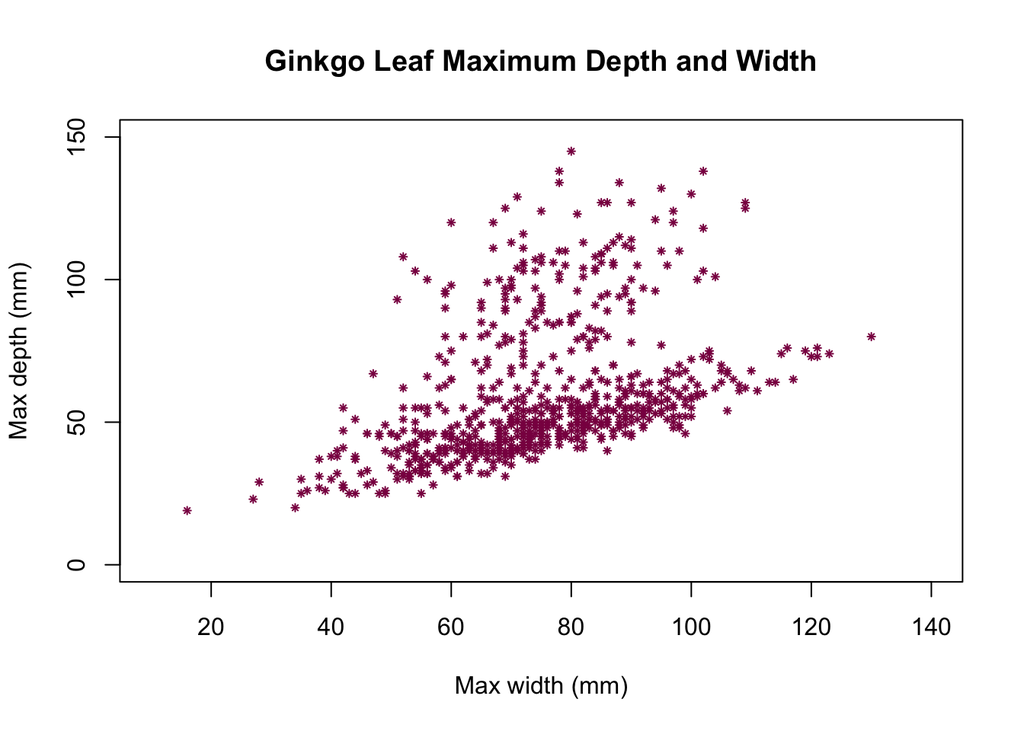

```r
plot(ginkgo$max_width, ginkgo$max_depth,
     main = "Ginkgo Leaf Maximum Depth and Width",
     xlab = "Max width (mm)",
     ylab = "Max depth (mm)",
     col = "deeppink4",
     pch = 8, cex = 0.5,
     xlim = c(10, 140),
     ylim = c(0, 150)
     )
```

### Histogram of Penguin Flipper lengths

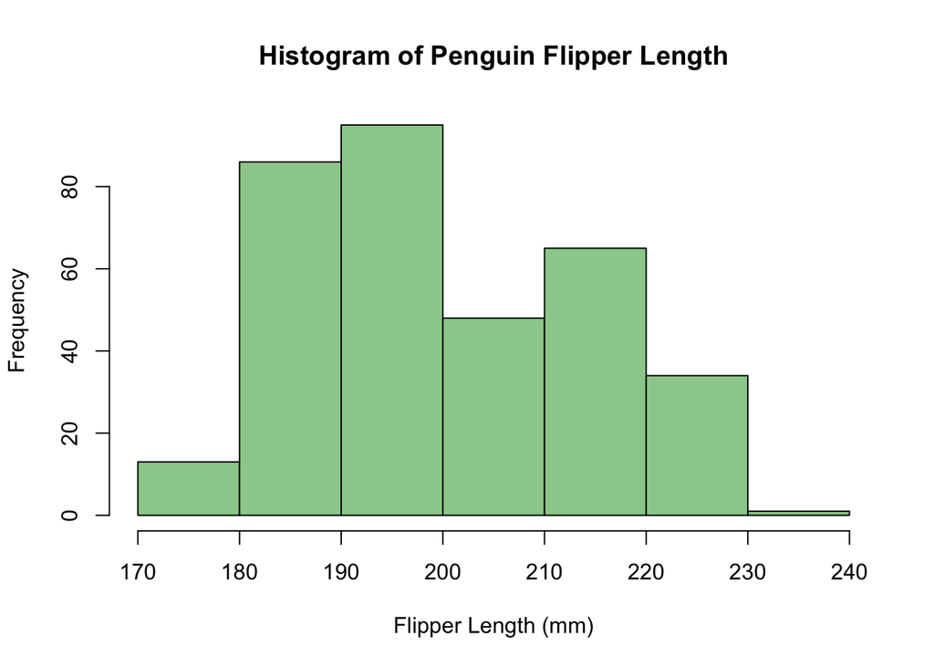

```r
hist(penguins$flipper_length_mm,
     breaks = 6,
     main = "Histogram of Penguin Flipper Length",
     xlab = "Flipper Length (mm)",
     col = "darkseagreen3")
```

### Boxplots of Ginkgo Data

- Ginkgo Petiole Length:

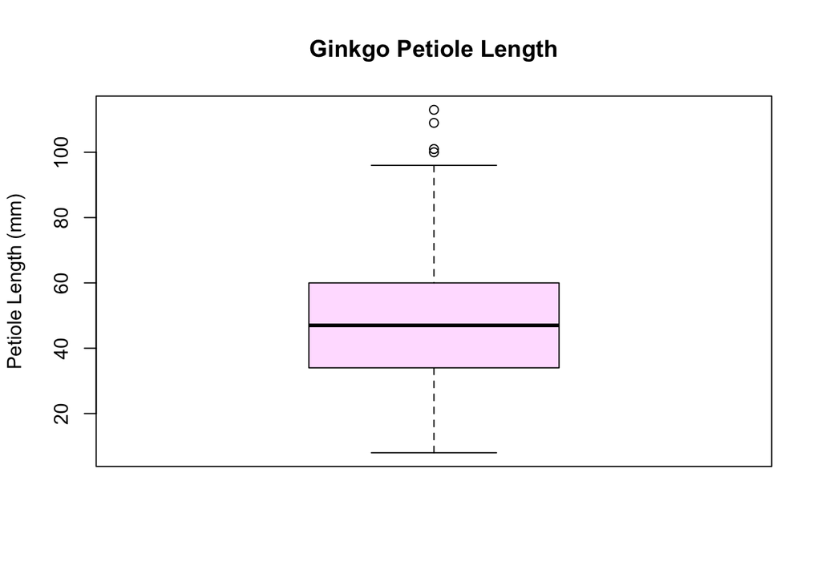

```r
boxplot(
  ginkgo$petiole_length,
  main = "Ginkgo Petiole Length",
  ylab = "Petiole Length (mm)",
  col = "thistle1"
)
```

- Conditional Boxplot
  - Created by using one of the continuous variables conditioned on the seeds_present column.

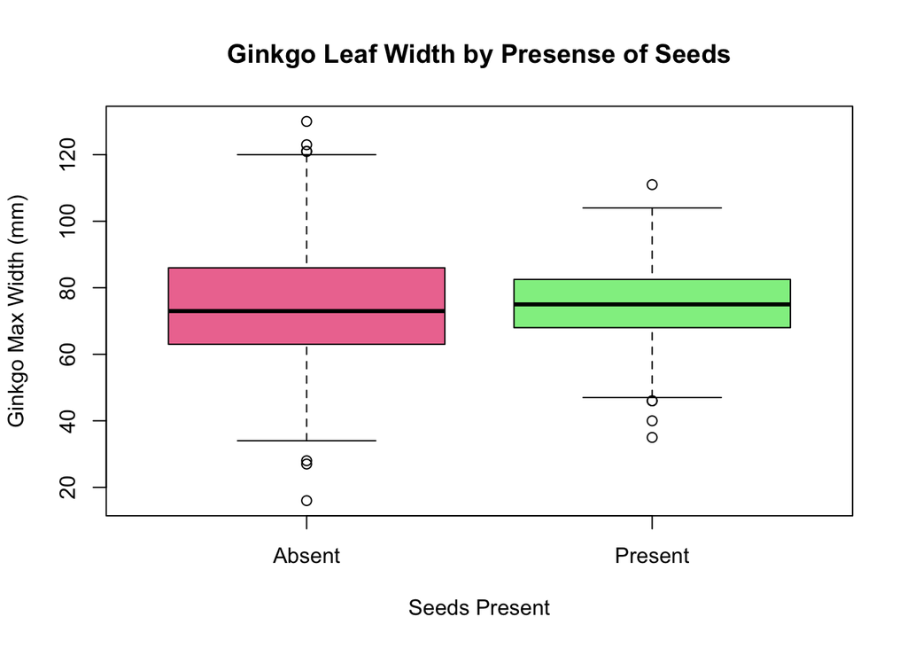

```r
## Conditional boxplot: max width conditioned by whether seeds were present at the time of observation.
boxplot(
  data = ginkgo, max_width ~ seeds_present,
  main = "Ginkgo Leaf Width by Presense of Seeds",
  xlab = "Seeds Present",
  ylab = "Ginkgo Max Width (mm)",
  names = c("Absent", "Present"),
  col = c("palevioletred2", "palegreen2")
)
```